# Simulation Project

Harris Wohl

# Overvew

The following procedure will demonstrate the properties of the exponential distribution and its relation to the normal distribution. This will be performed using random simulations in R. The source code and output of the various simulations will be included throughout the report.

# Sample mean vs. Theoretical Mean

Since we are given $\lambda = .2$ , and the mean of an exponential distribution is $1 / \lambda$, it can be deduced that the theoretical mean of the distribution is 5.

The following code produces 40 random variables that follow an exponential distribution, and calculates the mean of the sample.

```r
set.seed(8675309)
samean <- mean(rexp(40, .2))
samean
```

```
## [1] 4.590061
```

So the sample mean is approximately 4.59.

The following histogram shows the distribution of the random sample of exponential variables, as well as vertical lines to represent the sample mean and theoretical mean.

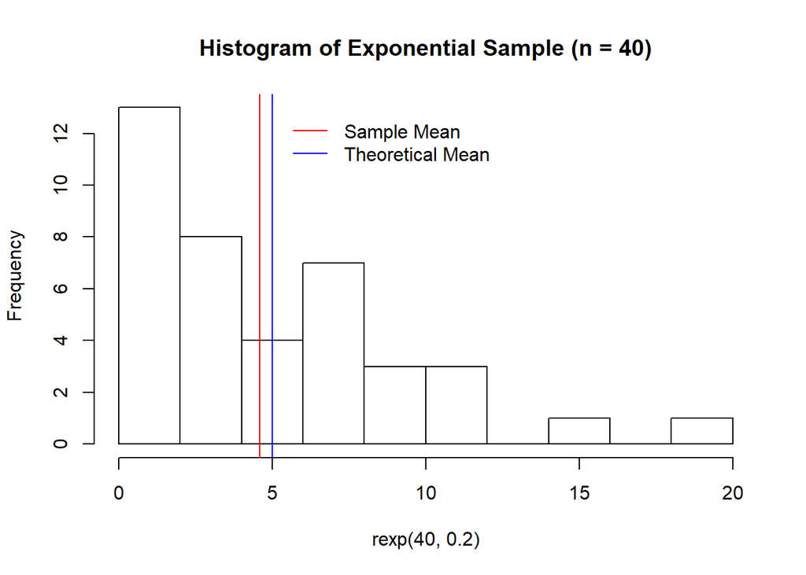

# Sample Variance vs. Theoretical Variance

Again, since we are given the formula for the theoretical standard deviation of an exponential distribution, $1 / \lambda$, it can be determined that the theoretical variance is 25.

The following code produces 40 random exponential variables and calculates the sample variance. The seed is set to 8675309 again, so the 40 random exponential values produced are the same as the sample produced to find the sample mean.

```r
set.seed(8675309)
savariance <- (sd(rexp(40, .2)))^2
savariance
```

```
## [1] 13.63944
```

The sample variance is approximately 13.64, which is a fair amount lower than the population variance. The sample mean was relatively close to the population mean, but the same cannot be said about the variance.

# Relation to Normal Distribution

By the central limit theorem, the distribution of the mean follows a normal distribution. The simulation I used to show this is as follows: I generated 40 random exponential variables and took the sample mean. This process was repeated a thousand times, yielding a distribution of the sample mean for 1000 trials of n = 40. The source code for this process is below. The histogram of the means is also below, note its resemblance to the shape of a normal distribution.

```r
set.seed(8675309)
means <- NULL
for(x in 1:1000){
        means <- c(means, mean(rexp(40, .2)))
}
```

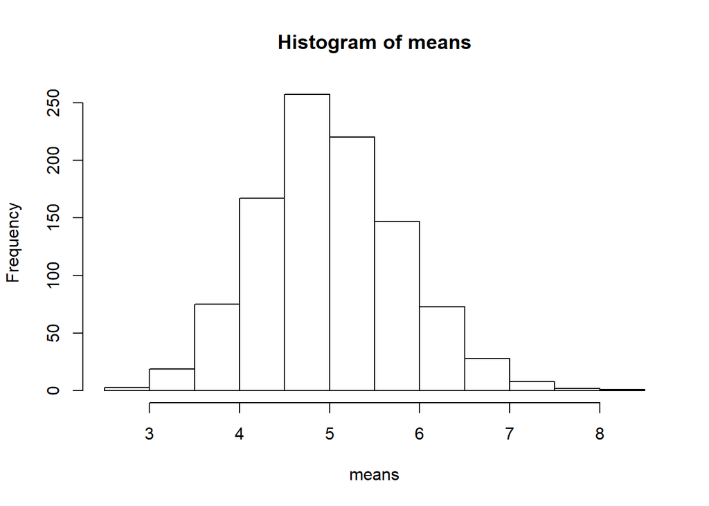